# Exploración de la riqueza y distribución espacial de comunidades vegetales

Análisis exploratorio con datos NEON

Author

Rojas M. / Matt7UC

Published

November 16, 2026

## 1. Introducción

La composición florística y riqueza de especies son atributos fundamentales para caracterizar la diversidad de las comunidades vegetales y comprender su variación espacial.

Este proyecto utiliza registros de vegetación del National Ecological Observatory Network (NEON), provenientes de diferentes sitios de monitoreo de Estados Unidos.

**Pregunta exploratoria:** ¿Cómo varía la riqueza de especies vegetales entre los sitios de monitoreo NEON?

## 2. Importación y caracterización de datos

Se utiliza una base de datos de cobertura vegetal de NEON, con información taxonómica, espacial y temporal.

```r
library(readr)
library(dplyr)
library(ggplot2)

# Importar base de datos NEON

datos_plant_cover <- read_csv(
  "../data/plant_cover.csv",
  show_col_types = FALSE
)

# Conocer dimensiones
dim(datos_plant_cover)
```

```
[1] 293078      7
```

```r
# Revisar variables
glimpse(datos_plant_cover)
```

```
Rows: 293,078
Columns: 7
$ species      <chr> "Galactia elliottii Nutt.", "Schizachyrium scoparium (Mic…
$ lat          <dbl> 28.05828, 28.09297, 28.05828, 28.09297, 28.09297, 28.0929…
$ lon          <dbl> -81.40287, -81.39933, -81.40287, -81.39933, -81.39933, -8…
$ sitename     <chr> "DSNY_DSNY_017_32.4.1", "DSNY_DSNY_006_32.2.1", "DSNY_DSN…
$ date         <date> 2019-11-04, 2019-11-04, 2019-11-04, 2019-11-04, 2019-11-…
$ canopy_cover <dbl> 5.0, 2.0, 0.5, 0.5, 16.0, 0.5, 1.0, 0.5, 8.0, 1.0, 6.0, 1…
$ uid          <chr> "a3c11564-d4a2-4b41-8a3e-eb848159c1f3", "454eeccd-4dc5-40…
```

### 2.1. Variables originales

La base de datos utilizada en este estudio contiene siete variables que permiten caracterizar los registros de vegetación, incluyendo información taxonómica, espacial, temporal y de cobertura vegetal.

A continuación, se presentan las variables originales utilizadas para el análisis, junto con su tipo de dato, descripción y ejemplos.

**Tabla 1.** Diccionario preliminar de las variables originales de la base de datos de vegetación NEON.

| Variable | Tipo | Qué representa | Ejemplo |
| --- | --- | --- | --- |
| `species` | Texto | Nombre científico de la especie vegetal registrada | *Galactia elliottii* Nutt. |
| `lat` | Numérica | Latitud de la parcela | `28.058282` |
| `lon` | Numérica | Longitud de la parcela | `-81.402874` |
| `sitename` | Texto | Identificador del sitio, parcela y subparcela | `DSNY_DSNY_017_32.4.1` |
| `date` | Fecha | Fecha en que se realizó el muestreo | `2019-11-04` |
| `canopy_cover` | Numérica | Porcentaje de cobertura de esa especie | `5`, `2`, `0.5`, etc. |
| `uid` | Texto | Identificador único de cada registro | `a3c11564-d4a2...` |

**Fuente:** Elaboración propia a partir de datos del National Ecological Observatory Network (NEON).

### 2.2. Caracterización general de la base de datos

Se presenta una síntesis del número de registros, variables y nombres de especies identificados.

```r
resumen_neon <- data.frame(
  Registros = nrow(datos_plant_cover),
  Variables = ncol(datos_plant_cover),
  Especies = n_distinct(
    datos_plant_cover$species,
    na.rm = TRUE
  )
)

knitr::kable(
  resumen_neon,
  caption = "Características generales de la base NEON"
)
```

Características generales de la base NEON

| Registros | Variables | Especies |
| --- | --- | --- |
| 293078 | 7 | 3035 |

## 3. Análisis exploratorio de riqueza vegetal

Se calculó la riqueza observada mediante el número de especies diferentes registradas por unidad de muestreo y fecha.

```r
riqueza_unidades <- datos_plant_cover %>%
  filter(
    !is.na(species),
    trimws(species) != "",
    !is.na(sitename),
    trimws(sitename) != "",
    !is.na(date)
  ) %>%
  mutate(
    sitio_neon = sub("_.*$", "", sitename)
  ) %>%
  group_by(sitio_neon, sitename, date) %>%
  summarise(
    riqueza = n_distinct(species),
    .groups = "drop"
  )

# Visualizar primeras unidades
knitr::kable(
  head(riqueza_unidades, 10),
  caption = "Riqueza observada por unidad de muestreo"
)
```

Riqueza observada por unidad de muestreo

| sitio_neon | sitename | date | riqueza |
| --- | --- | --- | --- |
| ABBY | ABBY_ABBY_001_31.1.1 | 2016-08-17 | 2 |
| ABBY | ABBY_ABBY_001_31.1.1 | 2017-07-07 | 6 |
| ABBY | ABBY_ABBY_001_31.1.1 | 2018-06-12 | 6 |
| ABBY | ABBY_ABBY_001_31.1.1 | 2019-06-12 | 3 |
| ABBY | ABBY_ABBY_001_31.4.1 | 2016-08-17 | 4 |
| ABBY | ABBY_ABBY_001_31.4.1 | 2017-07-07 | 6 |
| ABBY | ABBY_ABBY_001_31.4.1 | 2018-06-12 | 4 |
| ABBY | ABBY_ABBY_001_32.2.1 | 2016-08-17 | 8 |
| ABBY | ABBY_ABBY_001_32.2.1 | 2017-07-07 | 7 |
| ABBY | ABBY_ABBY_001_32.2.1 | 2018-06-12 | 6 |

## 4. Variación de la riqueza entre sitios NEON

La siguiente figura representa la distribución de la riqueza observada entre unidades de muestreo de diez sitios de monitoreo NEON.

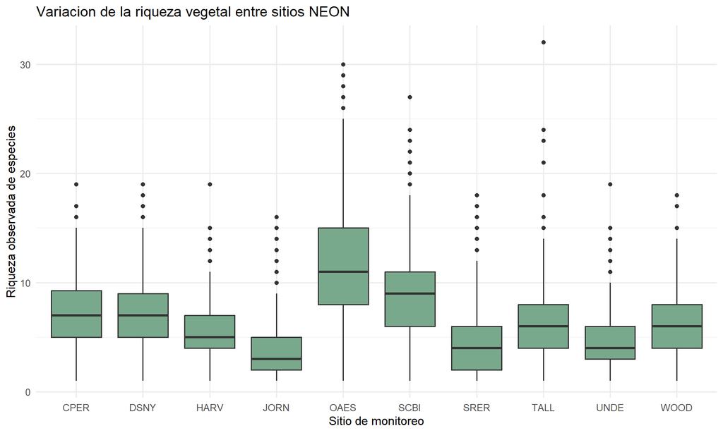

Figure 1: Variación de la riqueza observada entre sitios NEON.

```r
# Seleccionar sitios con mayor numero de evaluaciones
sitios_top <- riqueza_unidades %>%
  count(sitio_neon, name = "n_evaluaciones") %>%
  slice_max(
    n_evaluaciones,
    n = 10,
    with_ties = FALSE
  ) %>%
  pull(sitio_neon)

# Generar grafico
grafico_riqueza <- riqueza_unidades %>%
  filter(sitio_neon %in% sitios_top) %>%
  ggplot(aes(
    x = sitio_neon,
    y = riqueza
  )) +
  geom_boxplot(fill = "#79A98C") +
  labs(
    title = "Variacion de la riqueza vegetal entre sitios NEON",
    x = "Sitio de monitoreo",
    y = "Riqueza observada de especies"
  ) +
  theme_minimal(base_size = 12)

print(grafico_riqueza)
```

## 5. Discusión preliminar

La visualización permite explorar la variabilidad de la riqueza observada entre diferentes sitios de monitoreo NEON, identificando posibles diferencias en la distribución y dispersión de los valores registrados.

Sin embargo, estas diferencias deben interpretarse considerando las características de las unidades de muestreo, la variación temporal y las posibles diferencias en el esfuerzo de muestreo.

Por lo tanto, el análisis constituye una aproximación descriptiva que permite identificar patrones preliminares, sin establecer relaciones causales entre la ubicación geográfica y la diversidad vegetal.

## 6. Proyección de la investigación

Los procedimientos desarrollados mediante Quarto permitirán organizar de manera reproducible los análisis y visualizaciones de comunidades vegetales.

Estas herramientas podrán adaptarse posteriormente a mi tesis de magíster, enfocada en la variación florística y estructural de comunidades vegetales ribereñas y terrestres adyacentes a lo largo de un gradiente altitudinal.